# AI - Deep Learning Conference

Trenton Pulsipher

5/24/2019

# Intro

## What do you know of deep learning?

[figure not shown]

## What is AI? ML? DL? NN?

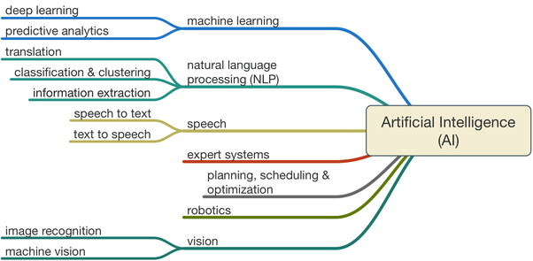

## What is AI? ML? DL? NN?

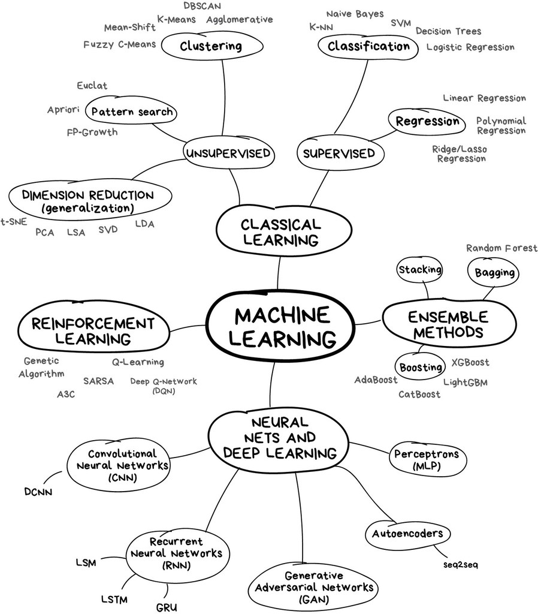

## Define AI, ML, DL, NN

AI is most often just a term for business people to describe Machine Learning (ML), which is a set of algorithms that allow statistical/mathematical models to “learn” and thus predict with greater accuracy than standard statistical models. That improved accuracy often comes at the expense of model interpretability or inference. In general, ML algorithms aren’t new, however, computing resource improvements and data size increases have enabled more prolific use of ML in the past five years.

## Define Data Science

Data Science is the confluence of statistical design, computer science, machine learning modeling, and the domain knowledge of researchers/experts. Data science teams often include a blend of data engineers, technical business analysts and project managers, statisticians, business intelligence (BI) developers, front-end and/or back-end developers (DevOps), and machine learning researchers. Most data scientists are either generalist data scientists, data engineers, or machine learning researchers, though this distinction is only a year or two old. I consider myself a generalist.

Test your own data science-yness using Mango Solutions’ questionnaire:

https://www.mango-solutions.com/radar/.

My results look like this https://www.mango-solutions.com/radar/?fs=true&r=6.0,4.7,5.7,4.1,3.0,4.7.

## Speakers

- Salesforce
- Twitter
- Change Healthcare
- Facebook
- Fidelity
- GE
- Research hospitals
- CVS / Aetna

## Topics

- AI Ethics
- Embedding
- Speech to Text (language agnostic)
- Object Recognition (eye tracking)
- Attention Mapping (Adobe, focus vs periphery)
- Model Governance
- Cautionary Tales

## Outline

1. Immediate Opportunities
2. Governance
3. Coming Opportunities & Cool Stuff

# Immediate Opportunities

## Embedding

> Definition: Convert Discrete to Continuous

Uses include:

- Building model features
- Feature compression
- Nearest neighbor search
- Transfer learning

## Speech to Text (Deep Speech)

- Mozilla Firefox
- 10,000 hours required to train the models adequately
- Iara Health: patient record transcribing
  - **Webinars?**
- Common Voice is their tool to crowdsource validation of models
- Future is to convert to Unicode to cover all languages into one model

## BOLA.AI

- Voice charting assistant (think periocharts)
- Boston based four person startup
- Contracts already with Eaglesoft, Curve, and 2nd largest DSO.
- Could do native integration in Dentrix for EHR

# Governance

## AI Ethics in Product Development

Must maintain ethics in

- Content / Product
- Process

Ethics are defined as:

- As beneficial as possible
- Respect human agency
- Allow human development
- Ensure social justice

## AI Ethics Concerns in Dentistry

- Who’s most likely to pay?
- Marketing to potential patients?
- Zip code / Income / Ethnicity

## Model Governance

[figure not shown]

## Model Governance Considerations

- Build models for all parts of the DS process
- Stress & QC test (watch for model decay)
- Can we file IP/Patent the product or algorithm
- Package management
- Hardware needs
- OECD principles standard on AI for Governance

## 4 V’s of Big Data

[figure not shown]

# Coming Opportunities & Cool Stuff

## Attention Mapping

Not just A/B testing - **any graphic design**

Zoya

## Challenges

- Calculating costs for being wrong
  - acting on false positives
  - not acting on false negatives

## Suggestions

- Keep Human-in-the-Loop
- Focus on “better” not cheaper
- Need to go live fast, then learn from it